# Mapping the Coronavirus Outbreak

Garrett Allen

01-28-2020

# Getting started

1. Clone your repo `appex04-[github_name]` to create a new project in RStudio Cloud under the STA 199 class space.
2. Configure git

```r
library(usethis)
use_git_config(user.name="Garrett.Allen", user.email="gpa5@duke.edu")
```

# Packages and Data

We’ll make use of the following packages.

```r
library(sf)
library(tidyverse)
```

There are two data files we will use: `world.shp`, `coronavirus.shp`. We’ll read each of these in with function `st_read()` and save them as `world` and `virus`.

```r
world <- st_read("data/world.shp", quiet = TRUE)
virus <- st_read("data/coronavirus.shp", quiet = TRUE)
nc <- st_read(system.file("shape/nc.shp", package = "sf"), quiet = TRUE)
```

# Tasks

## Task 1

Take a look at objects `world` and `virus`. How many fields exist for each object? What type of geometry is associated with each `sf` object?

```r
world
```

| name | abbrev | pop_est | gdp_md_est | lastcensus | economy | continent | region_un | subregion | geometry |
| --- | --- | --- | --- | --- | --- | --- | --- | --- | --- |
| Aruba | Aruba | 0.103065 | 2258.000 | 2010 | 6. Developing region | North America | Americas | Caribbean |  |
| Afghanistan | Afg. | 28.400000 | 22270.000 | 1979 | 7. Least developed region | Asia | Asia | Southern Asia |  |
| Angola | Ang. | 12.799293 | 110300.000 | 1970 | 7. Least developed region | Africa | Africa | Middle Africa |  |
| Anguilla | Ang. | 0.014436 | 108.900 | NA | 6. Developing region | North America | Americas | Caribbean |  |
| Albania | Alb. | 3.639453 | 21810.000 | 2001 | 6. Developing region | Europe | Europe | Southern Europe |  |
| Aland | Aland | 0.027153 | 1563.000 | NA | 2. Developed region: nonG7 | Europe | Europe | Northern Europe |  |
| Andorra | And. | 0.083888 | 3660.000 | 1989 | 2. Developed region: nonG7 | Europe | Europe | Southern Europe |  |
| United Arab Emirates | U.A.E. | 4.798491 | 184300.000 | 2010 | 6. Developing region | Asia | Asia | Western Asia |  |
| Argentina | Arg. | 40.913584 | 573900.000 | 2010 | 5. Emerging region: G20 | South America | Americas | South America |  |
| Armenia | Arm. | 2.967004 | 18770.000 | 2001 | 6. Developing region | Asia | Asia | Western Asia |  |

[output cut: 231 more lines]

In “world”, there are 241 observations of 9 fields. For this chart, the geometry is multipolygon.

```r
virus
```

| objectd | prvnc_s | cntry_r | lst_pdt | confrmd | suspctd | recovrd | deaths | cnfn_ss | geometry |
| --- | --- | --- | --- | --- | --- | --- | --- | --- | --- |
| 1 | Hubei | Mainland China | 1/25/2020 12am | 729 | NA | 32 | 39 | 729 |  |
| 2 | Guangdong | Mainland China | 1/25/2020 12am | 78 | NA | 2 | NA | 78 |  |
| 3 | Zhejiang | Mainland China | 1/25/2020 12am | 62 | NA | 1 | NA | 62 |  |
| 4 | Chongqing | Mainland China | 1/25/2020 12am | 57 | NA | NA | NA | 57 |  |
| 5 | Hunan | Mainland China | 1/25/2020 12am | 43 | NA | NA | NA | 43 |  |
| 6 | Anhui | Mainland China | 1/25/2020 12am | 39 | 4 | NA | NA | 43 |  |
| 7 | Beijing | Mainland China | 1/25/2020 12am | 36 | NA | 1 | NA | 36 |  |
| 8 | Shanghai | Mainland China | 1/25/2020 12am | 33 | 22 | 1 | NA | 55 |  |
| 9 | Henan | Mainland China | 1/25/2020 12am | 32 | 1 | NA | NA | 33 |  |
| 10 | Sichuan | Mainland China | 1/25/2020 12am | 28 | 4 | NA | NA | 32 |  |

[output cut: 34 more lines]

in “virus” there are 44 observations and also 9 fields. For this plot, the geometry is point.

## Task 2

#### Part 1

Use object `world` to create a world map of the countries. You’ll want to use functions `ggplot()` and `geom_sf()`.

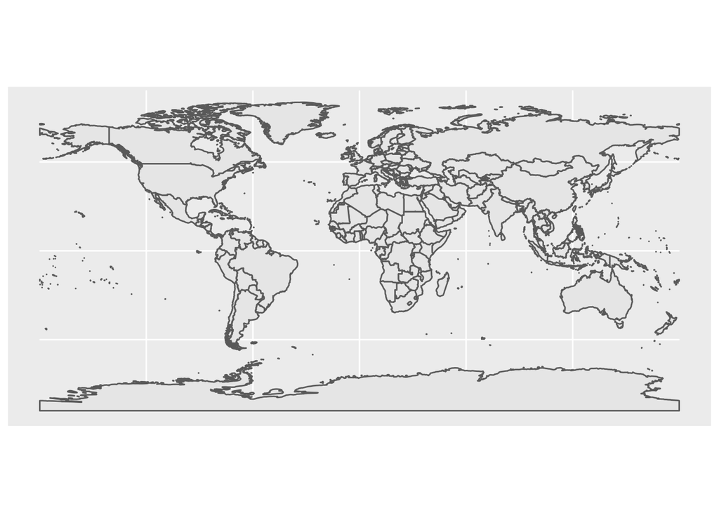

```r
ggplot(world) +
  geom_sf()
```

#### Part 2

Build on your map from Part 1 so that the countries have a fill color associated with the population estimate. Variable `pop_est` is in millions. Be sure to label your map.

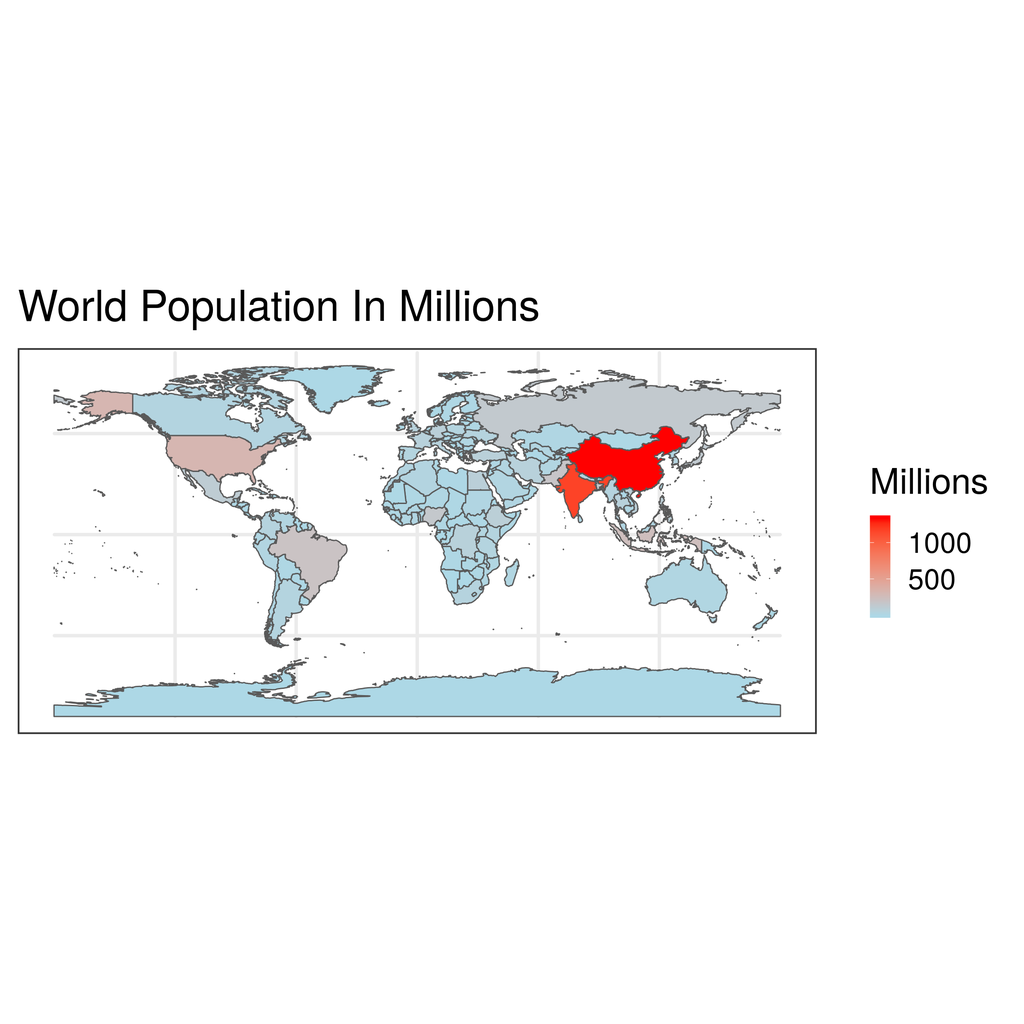

```r
ggplot(world) +
  geom_sf(aes(fill = pop_est),) +
  labs(title = "World Population In Millions", fill = "Millions") +
  scale_fill_gradient(low = "lightblue", high = "red") +
  theme_bw(base_size = 30)
```

## Task 3

Filter `world` for the country “China”. Save the result as `china`.

```r
china <- world %>%
  filter(name == "China")
```

Next, we’ll filter object `virus` for confirmed cases in China and save the result as `china_cv`. The code is given below.

```r
china_cv <- virus %>%
  filter(cntry_r == "Mainland China", !is.na(confrmd))
```

- `cntry_r == "Mainland China"` filters rows so we only keep information on China
- `!is.na(confrmd)` filters rows for where there is not a missing confirmed case of coronavirus

## Task 4

Use the template provided to overlay the point locations of the coronavirus in China with a map of China. Have the size of the points reflect the number of confirmed cases. Refer to slides 31-32 as a guide.

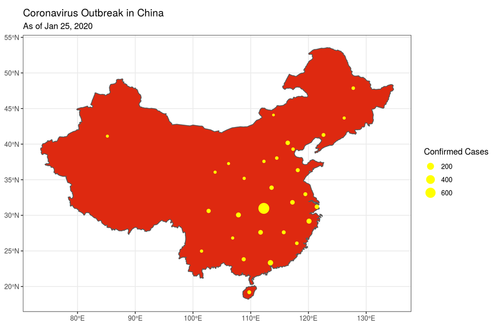

```r
ggplot(data = china) +
  geom_sf(fill = "#DE2910") +
  geom_sf(data = china_cv, aes(size = confrmd), color = "yellow", show.legend = "point") +
  labs(title = "Coronavirus Outbreak in China", subtitle = "As of Jan 25, 2020", size = "Confirmed Cases") +
  theme_bw()
```

*Hints:*

- you’ll need another `geom_sf()` layer
- set point colors as `color = "#FFDE00"`
- inside this second `geom_sf()` include `show.legend = "point"` to have the legend show points rather than squares

# Submission

## Stage, commit and push

1. Stage your modified files.
2. Commit your changes with an informative message.
3. Push your changes to your GitHub repo.
4. Verify your files were updated on GitHub.

# References

1. Simple Features for R vignette, https://r-spatial.github.io/sf/